# Infer ASVS with DADA2

Alicia McElwee

2024-02-28

# Before you start

## Set my seed

```r
# Setting the seed so randomized choices a reproducible
# Any number can be chosen
set.seed(5318008)
```

## Goals of this file

1. Use raw fastq files and generate quality plots to assess quality of reads.
2. Filter and trim out bad sequences and bases from our sequencing files.
3. Write out fastq files with high quality sequences
4. Evaluate the quality from our filter and trim.
5. Infer errors on forward and reverse reads individually
6. Infer ASVs on forward and reverse reads separately using the error models
7. Merged forward and reverse ASVs into continguous ASVs
8. Generate ASV counts table (ASV counts per sample) `otu_table` input for phyloseq

Output that we need: 1. ASV Count Table: `otu_table` 2. Taxonomy Table: `tax_table` 3. Sample Information: `sample_data` track the reads lost throughout DADA2 workflow

# Installing and Loading Libraries

```r
#install.packages("devtools")
library(devtools)
#devtools::install_github("benjjneb/dada2")
library(dada2)
#install.packages("tidyverse")
library(tidyverse)
```

# Load Data

```r
# Set the raw fastq file path to the raw sequencing files
# Path to the fastq files
raw_fastqs_path <- "data/01_DADA2/01_raw_gzipped_fastqs"
raw_fastqs_path
```

```
## [1] "data/01_DADA2/01_raw_gzipped_fastqs"
```

```r
# What files are in this path? Intuition Check
#list.files(raw_fastqs_path)

# How many files are there?
str(list.files(raw_fastqs_path))
```

```
##  chr [1:190] "022um-Control_S36_L001_R1_001.fastq.gz" ...
```

```r
# Create vector of forward reads
forward_reads <- list.files(raw_fastqs_path, pattern = "R1_001.fastq.gz", full.names = TRUE)
  # Intuition Check
head(forward_reads)
```

```
## [1] "data/01_DADA2/01_raw_gzipped_fastqs/022um-Control_S36_L001_R1_001.fastq.gz"
## [2] "data/01_DADA2/01_raw_gzipped_fastqs/20210602-MA-ABB1F_S31_L001_R1_001.fastq.gz"
## [3] "data/01_DADA2/01_raw_gzipped_fastqs/20210602-MA-ABB1P_S28_L001_R1_001.fastq.gz"
## [4] "data/01_DADA2/01_raw_gzipped_fastqs/20210602-MA-ABB1W_S58_L001_R1_001.fastq.gz"
## [5] "data/01_DADA2/01_raw_gzipped_fastqs/20210602-MA-ABS1F_S45_L001_R1_001.fastq.gz"
## [6] "data/01_DADA2/01_raw_gzipped_fastqs/20210602-MA-ABS1P_S65_L001_R1_001.fastq.gz"
```

```r
# Create vector of reverse reads
reverse_reads <- list.files(raw_fastqs_path, pattern = "R2_001.fastq.gz", full.names = TRUE)
  # Intuition Check
head(reverse_reads)
```

```
## [1] "data/01_DADA2/01_raw_gzipped_fastqs/022um-Control_S36_L001_R2_001.fastq.gz"
## [2] "data/01_DADA2/01_raw_gzipped_fastqs/20210602-MA-ABB1F_S31_L001_R2_001.fastq.gz"
## [3] "data/01_DADA2/01_raw_gzipped_fastqs/20210602-MA-ABB1P_S28_L001_R2_001.fastq.gz"
## [4] "data/01_DADA2/01_raw_gzipped_fastqs/20210602-MA-ABB1W_S58_L001_R2_001.fastq.gz"
## [5] "data/01_DADA2/01_raw_gzipped_fastqs/20210602-MA-ABS1F_S45_L001_R2_001.fastq.gz"
## [6] "data/01_DADA2/01_raw_gzipped_fastqs/20210602-MA-ABS1P_S65_L001_R2_001.fastq.gz"
```

# Raw Quality Plots

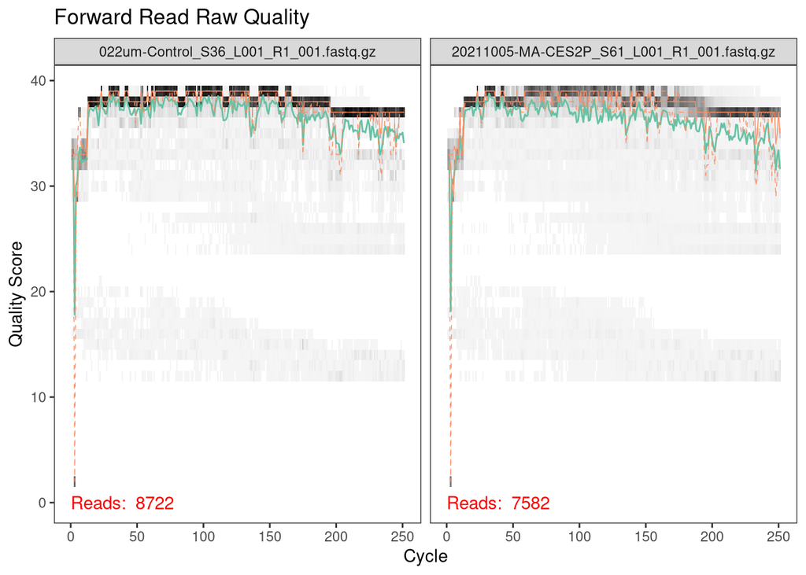

```r
# Randomly select 2 samples from dataset to evaluate
# random_samples <-
random_samples <- sample(1:length(reverse_reads), size = 2)

# Calculate and plot quality of these two samples
plotQualityProfile(forward_reads[random_samples]) +
  labs(title = "Forward Read Raw Quality")
```

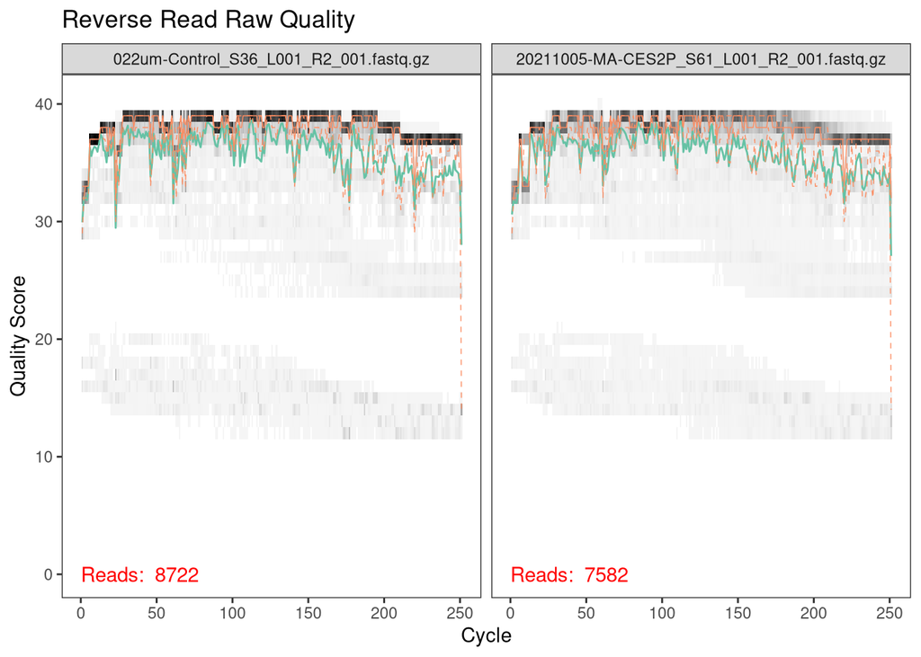

```r
plotQualityProfile(reverse_reads[random_samples]) +
  labs(title = "Reverse Read Raw Quality")
```